# Term Deposit Subscription Prediction

### Importing Libraries and Setting up the Notebook

```python
from sklearn.metrics import accuracy_score, f1_score, roc_auc_score, average_precision_score, confusion_matrix, classification_report
from sklearn.ensemble import RandomForestClassifier, AdaBoostClassifier, GradientBoostingClassifier
from sklearn.model_selection import train_test_split
from sklearn.linear_model import LogisticRegression
from sklearn.neighbors import KNeighborsClassifier
from sklearn.preprocessing import StandardScaler
from sklearn.model_selection import GridSearchCV
from sklearn.tree import DecisionTreeClassifier
from imblearn.over_sampling import SMOTE
from scipy.stats import chi2_contingency
from warnings import filterwarnings
from xgboost import XGBClassifier
import matplotlib.pyplot as plt
from sklearn.svm import SVC
import seaborn as sns
import pandas as pd
import numpy as np



pd.pandas.set_option('display.max_columns',None)
sns.set_theme()
filterwarnings('ignore')
%matplotlib inline
```

### Reading Data and Knowing the Primaries

```python
df = pd.read_csv(r'Dataset/customer_data.csv')
df.head()
```

|  | age | job | marital_status | education | defaulted | house_loan | personal_loan | con_medium | last_con_month | last_con_day | last_con_dur | num_con_this_camp | days_since_last_con | num_con_prev_camp | prev_camp_outcome | emp_var_rate | cpi | cci | euribor_3m | num_employed | subscribed |
| --- | --- | --- | --- | --- | --- | --- | --- | --- | --- | --- | --- | --- | --- | --- | --- | --- | --- | --- | --- | --- | --- |
| 0 | 56 | housemaid | married | basic.4y | no | no | no | telephone | may | mon | 261 | 1 | 999 | 0 | nonexistent | 1.1 | 93.994 | -36.4 | 4.857 | 5191.0 | no |
| 1 | 57 | services | married | high.school | unknown | no | no | telephone | may | mon | 149 | 1 | 999 | 0 | nonexistent | 1.1 | 93.994 | -36.4 | 4.857 | 5191.0 | no |
| 2 | 37 | services | married | high.school | no | yes | no | telephone | may | mon | 226 | 1 | 999 | 0 | nonexistent | 1.1 | 93.994 | -36.4 | 4.857 | 5191.0 | no |
| 3 | 40 | admin. | married | basic.6y | no | no | no | telephone | may | mon | 151 | 1 | 999 | 0 | nonexistent | 1.1 | 93.994 | -36.4 | 4.857 | 5191.0 | no |
| 4 | 56 | services | married | high.school | no | no | yes | telephone | may | mon | 307 | 1 | 999 | 0 | nonexistent | 1.1 | 93.994 | -36.4 | 4.857 | 5191.0 | no |

```python
df.shape
```

```
(41188, 21)
```

```python
df.info()
```

```
<class 'pandas.core.frame.DataFrame'>
RangeIndex: 41188 entries, 0 to 41187
Data columns (total 21 columns):
 #   Column               Non-Null Count  Dtype
---  ------               --------------  -----
 0   age                  41188 non-null  int64
 1   job                  41188 non-null  object
 2   marital_status       41188 non-null  object
 3   education            41188 non-null  object
 4   defaulted            41188 non-null  object
 5   house_loan           41188 non-null  object
 6   personal_loan        41188 non-null  object
 7   con_medium           41188 non-null  object
 8   last_con_month       41188 non-null  object
 9   last_con_day         41188 non-null  object
 10  last_con_dur         41188 non-null  int64
 11  num_con_this_camp    41188 non-null  int64
 12  days_since_last_con  41188 non-null  int64
 13  num_con_prev_camp    41188 non-null  int64
 14  prev_camp_outcome    41188 non-null  object
 15  emp_var_rate         41188 non-null  float64
 16  cpi                  41188 non-null  float64
 17  cci                  41188 non-null  float64
 18  euribor_3m           41188 non-null  float64
 19  num_employed         41188 non-null  float64
 20  subscribed           41188 non-null  object
dtypes: float64(5), int64(5), object(11)
memory usage: 6.6+ MB
```

### Checking for Duplicated Rows and Null Values

```python
df.duplicated().sum()
```

```
12
```

```python
df.drop_duplicates(inplace=True)
```

```python
df.isnull().sum()
```

```
age                    0
job                    0
marital_status         0
education              0
defaulted              0
house_loan             0
personal_loan          0
con_medium             0
last_con_month         0
last_con_day           0
last_con_dur           0
num_con_this_camp      0
days_since_last_con    0
num_con_prev_camp      0
prev_camp_outcome      0
emp_var_rate           0
cpi                    0
cci                    0
euribor_3m             0
num_employed           0
subscribed             0
dtype: int64
```

### Are there are any other abnormalities in the dataset?

```python
def unique_values(df, exclude_cols=[]):
    for col in df.columns:
        if col in exclude_cols:
            continue
        unique_vals = df[col].nunique()
        print(f"{col}: {unique_vals} unique values")
        if unique_vals < 25:
            print()
            print(df[col].unique())
        print("\n", 55 * "_", "\n")
```

```python
unique_values(df)
```

```
age: 78 unique values

 _______________________________________________________

job: 12 unique values

['housemaid' 'services' 'admin.' 'blue-collar' 'technician' 'retired'
 'management' 'unemployed' 'self-employed' 'unknown' 'entrepreneur'
 'student']

 _______________________________________________________

marital_status: 4 unique values

['married' 'single' 'divorced' 'unknown']

 _______________________________________________________

education: 8 unique values

['basic.4y' 'high.school' 'basic.6y' 'basic.9y' 'professional.course'
 'unknown' 'university.degree' 'illiterate']

 _______________________________________________________

defaulted: 3 unique values

['no' 'unknown' 'yes']

 _______________________________________________________

house_loan: 3 unique values

['no' 'yes' 'unknown']

 _______________________________________________________

personal_loan: 3 unique values

['no' 'yes' 'unknown']
```

[output cut: 60 more lines]

```

 _______________________________________________________

num_employed: 11 unique values

[5191.  5228.1 5195.8 5176.3 5099.1 5076.2 5017.5 5023.5 5008.7 4991.6
 4963.6]

 _______________________________________________________

subscribed: 2 unique values

['no' 'yes']

 _______________________________________________________
```

`emp_var_rate`, `cpi`, `cci`, `euribor_3m`, `num_employed` - All these columns represent countrywide indexes and values and they are not cusstomer specific. So, these features, though looking like discrete values based on the no. of unique values, they are continuous ones...

Null values seem to have been captured as `unknown` in many cat columns. Let's dive deep into that part to know the proportion...

One more thing to note here is, `prev_camp_outcome` has missing values captured in the name of `nonexistent`...

```python
def check_unknown_values(df):

    for column_name in df.columns:
        unique_values = df[column_name].unique().tolist()
        if 'unknown' in unique_values:
            values = df[column_name].value_counts()
            unknown_counts = values['unknown']
            total_count = len(df)
            unknown_percentage = (unknown_counts/ total_count) * 100
            print(values)
            print(f"\nPercentage of 'unknown' values in {column_name}: {unknown_percentage:.2f}%")
            print("\n", 55 * "_", "\n")
```

```python
check_unknown_values(df)
```

```
job
admin.           10419
blue-collar       9253
technician        6739
services          3967
management        2924
retired           1718
entrepreneur      1456
self-employed     1421
housemaid         1060
unemployed        1014
student            875
unknown            330
Name: count, dtype: int64

Percentage of 'unknown' values in job: 0.80%

 _______________________________________________________

marital_status
married     24921
single      11564
divorced     4611
unknown        80
Name: count, dtype: int64

Percentage of 'unknown' values in marital_status: 0.19%

 _______________________________________________________

education
university.degree      12164
high.school             9512
basic.9y                6045
professional.course     5240
basic.4y                4176
basic.6y                2291
unknown                 1730
illiterate                18
Name: count, dtype: int64
```

[output cut: 19 more lines]

```
Name: count, dtype: int64

Percentage of 'unknown' values in house_loan: 2.40%

 _______________________________________________________

personal_loan
no         33938
yes         6248
unknown      990
Name: count, dtype: int64

Percentage of 'unknown' values in personal_loan: 2.40%

 _______________________________________________________
```

Most of the features has negligible proportion of unknowns and only the feature named `defaulted` seems to have higher proportion of unknown values `(1/5 th of total)`...

Thing to note here is, we can't impute things in `defaulted` column without knowing whether a person has really defaulted or not.... This could well be a key factor to decide whether he/she would default in future... Let's decide on `defaulted` column upon further evaluation later on...

Also one good thing to note is, **target variable doesn't have any unknown values**...

We will deal with these things later when we handle cat columns...

### Handling Numerical and Categorial Data Seperately

#### Feature Seperation into Numerical and Categorical

```python
discrete_vars = []
categorical_vars = []
continuous_vars = []

for col in df.columns:
    unique_values = df[col].nunique()

    if col == 'age' or col == 'num_con_this_camp' or col == 'days_since_last_con' or col == 'num_con_prev_camp':
        discrete_vars.append(col)
    elif df[col].dtype == 'object':
        categorical_vars.append(col)
    else:
        continuous_vars.append(col)

print("Discrete Variables:\n")
print(discrete_vars)
print("\n", 55 * "_", "\n")
print("Categorical Variables:\n")
print(categorical_vars)
print("\n", 55 * "_", "\n")
print("Continuous Variables:\n")
print(continuous_vars)
```

```
Discrete Variables:

['age', 'num_con_this_camp', 'days_since_last_con', 'num_con_prev_camp']

 _______________________________________________________

Categorical Variables:

['job', 'marital_status', 'education', 'defaulted', 'house_loan', 'personal_loan', 'con_medium', 'last_con_month', 'last_con_day', 'prev_camp_outcome', 'subscribed']

 _______________________________________________________

Continuous Variables:

['last_con_dur', 'emp_var_rate', 'cpi', 'cci', 'euribor_3m', 'num_employed']
```

#### Handling Discrete Variables

```python
for column in discrete_vars:
    print(column, ':\n')
    print(df[column].unique())
    print("\n", 55 * "_", "\n")
```

```
age :

[56 57 37 40 45 59 41 24 25 29 35 54 46 50 39 30 55 49 34 52 58 32 38 44
 42 60 53 47 51 48 33 31 43 36 28 27 26 22 23 20 21 61 19 18 70 66 76 67
 73 88 95 77 68 75 63 80 62 65 72 82 64 71 69 78 85 79 83 81 74 17 87 91
 86 98 94 84 92 89]

 _______________________________________________________

num_con_this_camp :

[ 1  2  3  4  5  6  7  8  9 10 11 12 13 19 18 23 14 22 25 16 17 15 20 56
 39 35 42 28 26 27 32 21 24 29 31 30 41 37 40 33 34 43]

 _______________________________________________________

days_since_last_con :

[999   6   4   3   5   1   0  10   7   8   9  11   2  12  13  14  15  16
  21  17  18  22  25  26  19  27  20]

 _______________________________________________________

num_con_prev_camp :

[0 1 2 3 4 5 6 7]

 _______________________________________________________
```

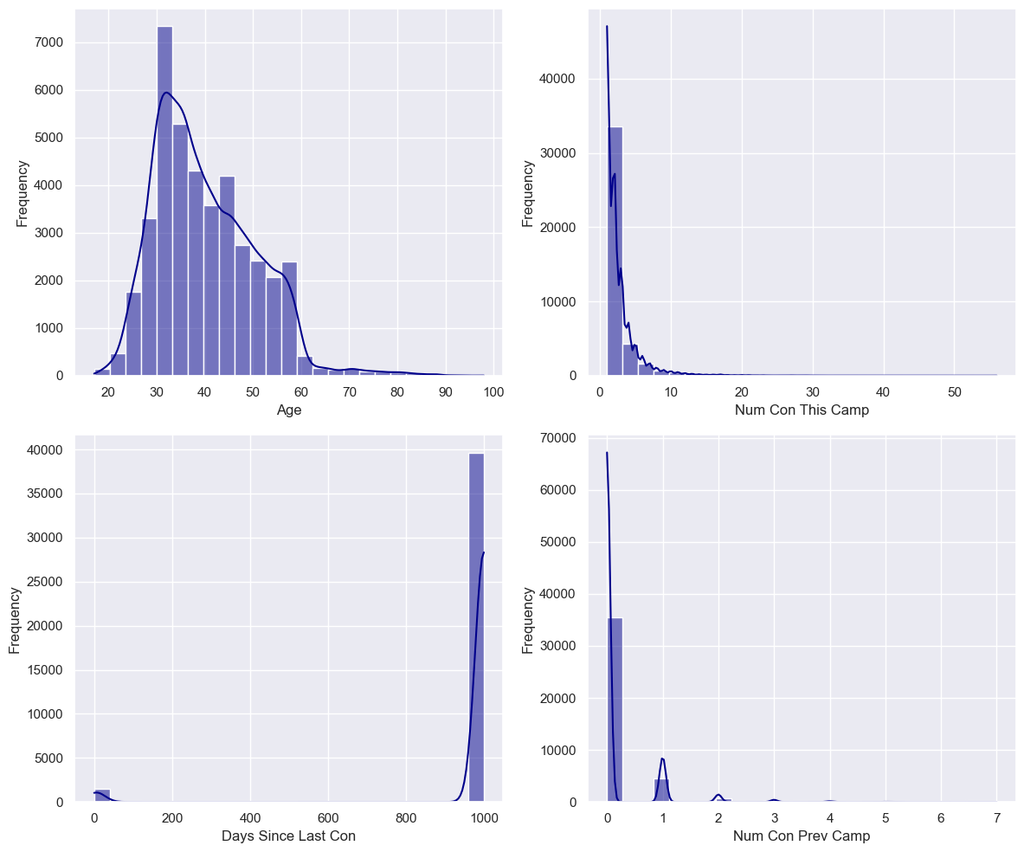

```python
num_plots = len(discrete_vars)

num_rows = (num_plots + 1) // 2  # Number of rows for subplots

fig, axes = plt.subplots(num_rows, 2, figsize=(12, 5 * num_rows))

for i, feature in enumerate(discrete_vars):

    data = df.copy()

    row = i // 2
    col = i % 2
    ax = axes[row, col]

    sns.histplot(data[feature], ax=ax, bins=25, kde=True, color='darkblue')
    ax.set_xlabel(feature.replace('_', ' ').title())
    ax.set_ylabel("Frequency")

# Remove any empty subplots
if num_plots < num_rows * 2:
    fig.delaxes(axes[num_rows-1, 1])

plt.tight_layout()
plt.show()
```

Age looks a bit right skewed because of few outliers and there seems to exist, an interval which holds the most frequent values... Except for age nothing seems to give meaningful insight... So, digging deeper...

```python
for column in discrete_vars:
    if column != 'age':
        print(df[column].value_counts())
        print("\n", 55 * "_", "\n")
```

```
num_con_this_camp
1     17634
2     10568
3      5340
4      2650
5      1599
6       979
7       629
8       400
9       283
10      225
11      177
12      125
13       92
14       69
```

[output cut: 76 more lines]

- As we can see now, in `num_con_this_camp` - `Top 5 - 6` values dominates the distribution...`Top 3` values appears in `81%` of total no. of instances...
- Whereas in `days_since_last_con` - `999` seems to dominate the frequency distribution... Some people, softwares and databases still use and understand `999` or `-999` as null value in numerical columns... So, this column seems to be filled with more than `96%` of null values. So, it would be inappropriate to impute those many values... So, dropping would be ideal...
- In `num_con_prev_camp` - `0` seems to dominate the frequency distribution...`86%` of customers haven't had any call at all during previous campaign... This might be because the campaign now being conducted on new set of customers for the most part. So, this feature doesn't hold any value at all... So, we would consider dropping this as well...

All three have huge imbalance which is of a scale we can't even think of addressing... Still let's plot these against target variable and take a call...

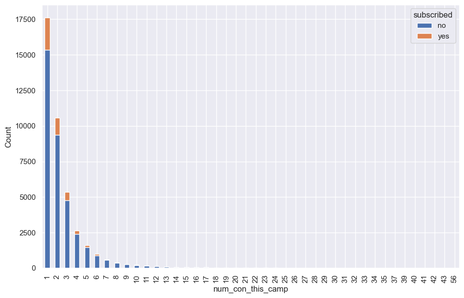

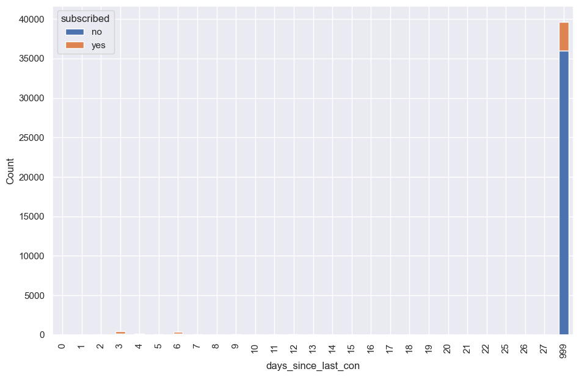

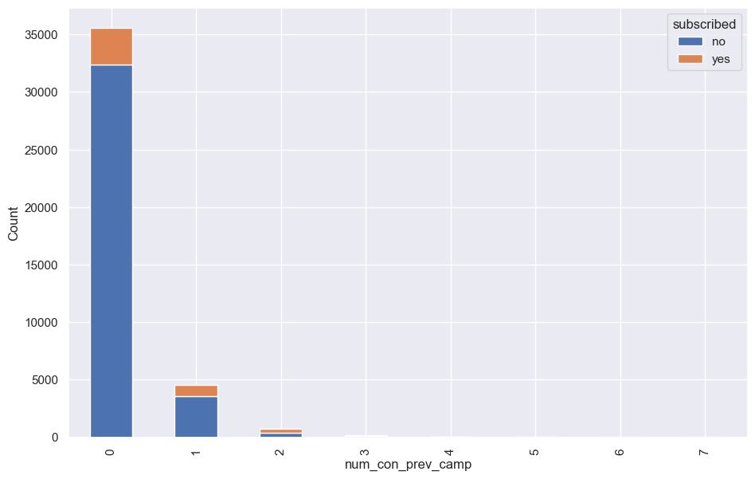

```python
def plot_discrete_vars(df, discrete_vars, target_var):
    for var in discrete_vars:
        if var != 'age':
            fig, ax = plt.subplots(figsize=(11, 7))
            grouped_data = df.groupby([var, target_var]).size().unstack()
            grouped_data.plot(kind='bar', stacked=True, ax=ax)
            ax.set_xlabel(var)
            ax.set_ylabel('Count')
            ax.legend(title=target_var)
            plt.show()

plot_discrete_vars(df, discrete_vars, 'subscribed')
```

As we can see, these features creates huge imbalance even when plotted against target variable... Also, they visibly are not contributing much to the desirable target which is 'yes'... Let's correlate with target var and confirm...

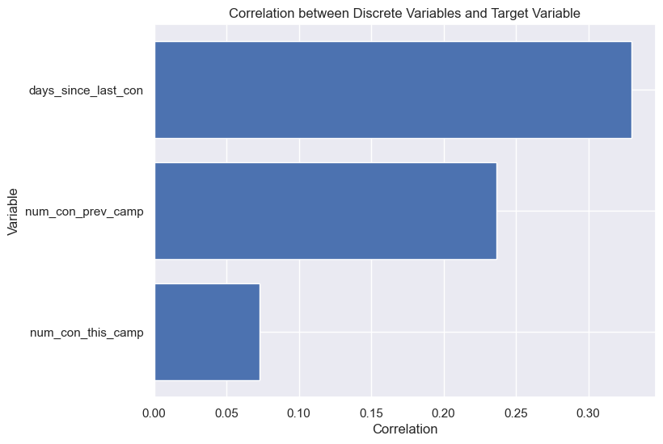

```python
def calculate_correlation(df, discrete_vars, target_var):
    correlations = []
    for var in discrete_vars:
        if var != 'age':
            crosstab = pd.crosstab(df[var], df[target_var])
            chi2, _, _, _ = chi2_contingency(crosstab)
            n = crosstab.sum().sum()
            phi = np.sqrt(chi2 / n)
            correlations.append((var, phi))

    return correlations

def plot_correlation(correlations):
    df_corr = pd.DataFrame(correlations, columns=['Variable', 'Correlation'])
    df_corr.sort_values(by='Correlation', inplace=True)

    fig, ax = plt.subplots(figsize=(8, 6))
    ax.barh(df_corr['Variable'], df_corr['Correlation'])
    ax.set_xlabel('Correlation')
    ax.set_ylabel('Variable')
    ax.set_title('Correlation between Discrete Variables and Target Variable')
    plt.show()

correlations = calculate_correlation(df, discrete_vars, 'subscribed')
plot_correlation(correlations)
```

```python
df.drop(columns = discrete_vars[1:], inplace=True)
```

Let's move towards continuous variables now...

#### Handling Continuous Variables

```python
continuous_vars
```

```
['last_con_dur', 'emp_var_rate', 'cpi', 'cci', 'euribor_3m', 'num_employed']
```

```python
def count_outliers(df):
    outliers = {}
    for col in df.select_dtypes(include='number').columns:
        q1 = df[col].quantile(0.25)
        q3 = df[col].quantile(0.75)
        iqr = q3 - q1
        upper_bound = q3 + (1.5 * iqr)
        lower_bound = q1 - (1.5 * iqr)
        num_outliers = len(df[(df[col] > upper_bound) | (df[col] < lower_bound)])
        percent_outliers = (num_outliers / len(df)) * 100
        outliers[col] = {'count': num_outliers, 'percent': percent_outliers}
    return outliers
```

```python
outliers = count_outliers(df)
for col, info in outliers.items():
    print(f"Column: {col}")
    print(f"Count of outliers: {info['count']}")
    print(f"Percentage of outliers: {round(info['percent'], 2)}%")
    print()
```

```
Column: age
Count of outliers: 468
Percentage of outliers: 1.14%

Column: last_con_dur
Count of outliers: 2963
Percentage of outliers: 7.2%

Column: emp_var_rate
Count of outliers: 0
Percentage of outliers: 0.0%

Column: cpi
Count of outliers: 0
Percentage of outliers: 0.0%

Column: cci
Count of outliers: 446
Percentage of outliers: 1.08%

Column: euribor_3m
Count of outliers: 0
Percentage of outliers: 0.0%

Column: num_employed
Count of outliers: 0
Percentage of outliers: 0.0%
```

```python
df['last_con_dur'] = df['last_con_dur'].clip(upper=df['last_con_dur'].quantile(0.92))
df['age'] = df['age'].clip(upper=df['age'].quantile(0.98))
df['cci'] = df['cci'].clip(upper=df['cci'].quantile(0.98))
```

```python
outliers = count_outliers(df)
for col, info in outliers.items():
    print(f"Column: {col}")
    print(f"Count of outliers: {info['count']}")
    print(f"Percentage of outliers: {round(info['percent'], 2)}%")
    print()
```

```
Column: age
Count of outliers: 0
Percentage of outliers: 0.0%

Column: last_con_dur
Count of outliers: 0
Percentage of outliers: 0.0%

Column: emp_var_rate
Count of outliers: 0
Percentage of outliers: 0.0%

Column: cpi
Count of outliers: 0
Percentage of outliers: 0.0%

Column: cci
Count of outliers: 0
Percentage of outliers: 0.0%

Column: euribor_3m
Count of outliers: 0
Percentage of outliers: 0.0%

Column: num_employed
Count of outliers: 0
Percentage of outliers: 0.0%
```

```python
def get_column_ranges(df):
    ranges = {}
    for column in continuous_vars:
        column_min = df[column].min()
        column_max = df[column].max()
        column_range = column_max - column_min
        ranges[column] = [column_min, column_max, column_range]
    return ranges
```

```python
ranges = get_column_ranges(df)

for column, values in ranges.items():
    print(f"Column: {column}")
    print(f"Minimum: {values[0]}, Maximum: {values[1]}, Range: {values[2]}")
    print()
```

```
Column: last_con_dur
Minimum: 0, Maximum: 614, Range: 614

Column: emp_var_rate
Minimum: -3.4, Maximum: 1.4, Range: 4.8

Column: cpi
Minimum: 92.201, Maximum: 94.767, Range: 2.5660000000000025

Column: cci
Minimum: -50.8, Maximum: -30.1, Range: 20.699999999999996

Column: euribor_3m
Minimum: 0.634, Maximum: 5.045, Range: 4.411

Column: num_employed
Minimum: 4963.6, Maximum: 5228.1, Range: 264.5
```

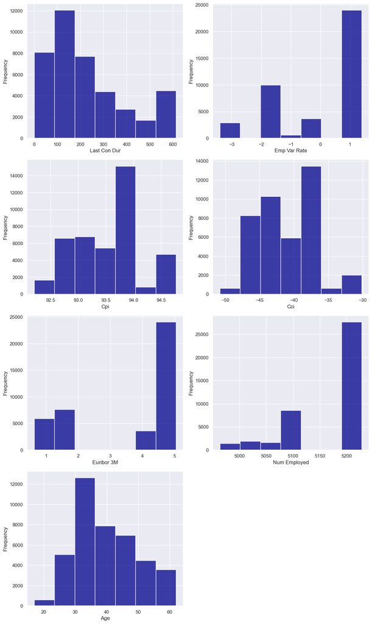

```python
num_plots = len(continuous_vars) + 1

num_rows = (num_plots + 1) // 2  # Number of rows for subplots

fig, axes = plt.subplots(num_rows, 2, figsize=(12, 5 * num_rows))

for i, feature in enumerate(continuous_vars + ['age']):
    data = df.copy()

    row = i // 2
    col = i % 2
    ax = axes[row, col]

    sns.histplot(data[feature], ax=ax, bins=7, color='darkblue')
    ax.set_xlabel(feature.replace('_', ' ').title())
    ax.set_ylabel("Frequency")

# Remove any empty subplots
if num_plots < num_rows * 2:
    fig.delaxes(axes[num_rows-1, 1])

plt.tight_layout()
plt.show()
```

Both the distributions as well as ranges suggest that it would be better if we do scaling... So, let's do scaling after split...

Now let's dive into the most important part which is categorical variables...

#### Handling Categorical Variables

```python
categorical_vars
```

```
['job',
 'marital_status',
 'education',
 'defaulted',
 'house_loan',
 'personal_loan',
 'con_medium',
 'last_con_month',
 'last_con_day',
 'prev_camp_outcome',
 'subscribed']
```

```python
ordinal_cols = ['education']

nominal_cols = [col for col in categorical_vars if col not in ordinal_cols and col != 'subscribed']
```

```python
for column in categorical_vars:
    print(column, ':\n')
    print(df[column].unique())
    print("\n", 55 * "_", "\n")
```

```
job :

['housemaid' 'services' 'admin.' 'blue-collar' 'technician' 'retired'
 'management' 'unemployed' 'self-employed' 'unknown' 'entrepreneur'
 'student']

 _______________________________________________________

marital_status :

['married' 'single' 'divorced' 'unknown']

 _______________________________________________________

education :

['basic.4y' 'high.school' 'basic.6y' 'basic.9y' 'professional.course'
 'unknown' 'university.degree' 'illiterate']

 _______________________________________________________

defaulted :

['no' 'unknown' 'yes']

 _______________________________________________________

house_loan :

['no' 'yes' 'unknown']

 _______________________________________________________

personal_loan :

['no' 'yes' 'unknown']

 _______________________________________________________

con_medium :
```

[output cut: 13 more lines]

```
['mon' 'tue' 'wed' 'thu' 'fri']

 _______________________________________________________

prev_camp_outcome :

['nonexistent' 'failure' 'success']

 _______________________________________________________

subscribed :

['no' 'yes']

 _______________________________________________________
```

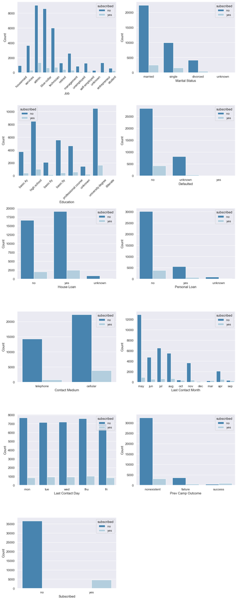

```python
num_plots = len(categorical_vars)
num_rows = (num_plots + 1) // 2

fig, axes = plt.subplots(num_rows, 2, figsize=(12, 5 * num_rows))

for i, feature in enumerate(categorical_vars):

    data = df.copy()

    row = i // 2
    col = i % 2
    ax = axes[row, col]

    sns.countplot(data=data, x=feature, hue='subscribed', ax=ax, palette='Blues_r')
    ax.set_xlabel(feature.replace('_', ' ').title().replace('Con', 'Contact'))
    ax.set_ylabel('Count')

    if feature in ['job', 'education']:
        ax.tick_params(axis='x', rotation=45)

# Remove any empty subplots
if num_plots < num_rows * 2:
    fig.delaxes(axes[num_rows-1, 1])

plt.tight_layout()
plt.show()
```

For almost all values, customers who haven't subscribed seems to dominate, which shows that there's a huge imbalance in the dataset leaning towards `no`. This we would address after splitting and scaling has been done...

From the plots, we can observe that `last_con_day` column doesn't seem to produce variable results on different days... So, it wouldn't contribute in anyway to the model... Let's drop it...

```python
df.drop(columns = 'last_con_day', inplace=True)
nominal_cols.remove('last_con_day')
```

#### Handling Unknowns and Encoding Categorical Variables

```python
df.replace('unknown', np.nan, inplace=True)
df.replace('nonexistent', np.nan, inplace=True)
```

```python
df.isnull().sum()
```

```
age                      0
job                    330
marital_status          80
education             1730
defaulted             8596
house_loan             990
personal_loan          990
con_medium               0
last_con_month           0
last_con_dur             0
prev_camp_outcome    35551
emp_var_rate             0
cpi                      0
cci                      0
euribor_3m               0
num_employed             0
subscribed               0
dtype: int64
```

```python
round(df.isnull().sum() / len(df) * 100, 2)
```

```
age                   0.00
job                   0.80
marital_status        0.19
education             4.20
defaulted            20.88
house_loan            2.40
personal_loan         2.40
con_medium            0.00
last_con_month        0.00
last_con_dur          0.00
prev_camp_outcome    86.34
emp_var_rate          0.00
cpi                   0.00
cci                   0.00
euribor_3m            0.00
num_employed          0.00
subscribed            0.00
dtype: float64
```

`prev_camp_outcome` has more than 86% null values... So, its better if we drop this column altogether

```python
df.drop(columns='prev_camp_outcome', inplace=True)
nominal_cols.remove('prev_camp_outcome')
```

Let's first encode values except for NaN and then impute values for NaN...

```python
categorical_vars
```

```
['job',
 'marital_status',
 'education',
 'defaulted',
 'house_loan',
 'personal_loan',
 'con_medium',
 'last_con_month',
 'last_con_day',
 'prev_camp_outcome',
 'subscribed']
```

Let's first encode the target variable...

```python
df['subscribed'].replace({'no': 0, 'yes': 1}, inplace=True)
```

`education` column is ordinal... So, we should define the order based on some reasoning and then proceed with encoding...

```python
df.groupby('subscribed')['education'].value_counts()
```

```
subscribed  education
0           university.degree      10495
            high.school             8481
            basic.9y                5572
            professional.course     4645
            basic.4y                3748
            basic.6y                2103
            illiterate                14
1           university.degree       1669
            high.school             1031
            professional.course      595
            basic.9y                 473
            basic.4y                 428
            basic.6y                 188
            illiterate                 4
Name: count, dtype: int64
```

```python
education_order = {
    'university.degree': 5,
    'high.school': 4,
    'professional.course': 3,
    'basic.9y': 2,
    'basic.4y': 1,
    'basic.6y': 1,
    'illiterate': 0
}

df['education'] = df['education'].map(education_order)
```

```python
nominal_cols
```

```
['job',
 'marital_status',
 'defaulted',
 'house_loan',
 'personal_loan',
 'con_medium',
 'last_con_month']
```

Now, let's first encode boolean cols which has `yes`, `no` values in them...

```python
encoded_cols = []
for col in nominal_cols:
    unique_values = df[col].unique().tolist()
    if "yes" in unique_values and "no" in unique_values:
        df[col] = df[col].replace({"no": 0, "yes": 1})
        encoded_cols.append(col)
        print(f"'{col}' column has got encoded")
```

```
'defaulted' column has got encoded
'house_loan' column has got encoded
'personal_loan' column has got encoded
```

```python
nominal_cols = [col for col in nominal_cols if col not in encoded_cols]
nominal_cols
```

```
['job', 'marital_status', 'con_medium', 'last_con_month']
```

Let's do one-hot-encoding now for all these cols...

```python
df[nominal_cols].nunique()
```

```
job               11
marital_status     3
con_medium         2
last_con_month    10
dtype: int64
```

```python
df.dropna(subset=['job', 'marital_status'], axis=0, inplace=True)
df.shape
```

```
(40775, 16)
```

```python
encoded_df = pd.get_dummies(df, columns=['job', 'marital_status', 'con_medium', 'last_con_month'], drop_first=True, dtype='int')
```

```python
encoded_df.info()
```

```
<class 'pandas.core.frame.DataFrame'>
Index: 40775 entries, 0 to 41187
Data columns (total 34 columns):
 #   Column                  Non-Null Count  Dtype
---  ------                  --------------  -----
 0   age                     40775 non-null  int64
 1   education               39180 non-null  float64
 2   defaulted               32340 non-null  float64
 3   house_loan              39791 non-null  float64
 4   personal_loan           39791 non-null  float64
 5   last_con_dur            40775 non-null  int64
 6   emp_var_rate            40775 non-null  float64
 7   cpi                     40775 non-null  float64
 8   cci                     40775 non-null  float64
 9   euribor_3m              40775 non-null  float64
```

[output cut: 26 more lines]

Everything seems to have got converted into numeric values... Now, let's impute values for NaN...

```python
def null_cols(df):
    missing = df.columns[df.isnull().sum() != 0]
    return missing
```

```python
cols_to_impute = null_cols(encoded_df)
cols_to_impute
```

```
Index(['education', 'defaulted', 'house_loan', 'personal_loan'], dtype='object')
```

```python
from sklearn.impute import KNNImputer

imputer = KNNImputer(n_neighbors=5)
encoded_df[cols_to_impute] = imputer.fit_transform(encoded_df[cols_to_impute])
```

```python
null_cols(encoded_df)
```

```
Index([], dtype='object')
```

Now we have successfully handled null values...

```python
encoded_df.head()
```

|  | age | education | defaulted | house_loan | personal_loan | last_con_dur | emp_var_rate | cpi | cci | euribor_3m | num_employed | subscribed | job_blue-collar | job_entrepreneur | job_housemaid | job_management | job_retired | job_self-employed | job_services | job_student | job_technician | job_unemployed | marital_status_married | marital_status_single | con_medium_telephone | last_con_month_aug | last_con_month_dec | last_con_month_jul | last_con_month_jun | … |
| --- | --- | --- | --- | --- | --- | --- | --- | --- | --- | --- | --- | --- | --- | --- | --- | --- | --- | --- | --- | --- | --- | --- | --- | --- | --- | --- | --- | --- | --- | --- |
| 0 | 56 | 1.0 | 0.0 | 0.0 | 0.0 | 261 | 1.1 | 93.994 | -36.4 | 4.857 | 5191.0 | 0 | 0 | 0 | 1 | 0 | 0 | 0 | 0 | 0 | 0 | 0 | 1 | 0 | 1 | 0 | 0 | 0 | 0 | … |
| 1 | 57 | 4.0 | 0.0 | 0.0 | 0.0 | 149 | 1.1 | 93.994 | -36.4 | 4.857 | 5191.0 | 0 | 0 | 0 | 0 | 0 | 0 | 0 | 1 | 0 | 0 | 0 | 1 | 0 | 1 | 0 | 0 | 0 | 0 | … |
| 2 | 37 | 4.0 | 0.0 | 1.0 | 0.0 | 226 | 1.1 | 93.994 | -36.4 | 4.857 | 5191.0 | 0 | 0 | 0 | 0 | 0 | 0 | 0 | 1 | 0 | 0 | 0 | 1 | 0 | 1 | 0 | 0 | 0 | 0 | … |
| 3 | 40 | 1.0 | 0.0 | 0.0 | 0.0 | 151 | 1.1 | 93.994 | -36.4 | 4.857 | 5191.0 | 0 | 0 | 0 | 0 | 0 | 0 | 0 | 0 | 0 | 0 | 0 | 1 | 0 | 1 | 0 | 0 | 0 | 0 | … |
| 4 | 56 | 4.0 | 0.0 | 0.0 | 1.0 | 307 | 1.1 | 93.994 | -36.4 | 4.857 | 5191.0 | 0 | 0 | 0 | 0 | 0 | 0 | 0 | 1 | 0 | 0 | 0 | 1 | 0 | 1 | 0 | 0 | 0 | 0 | … |

```python
encoded_df.columns
```

```
Index(['age', 'education', 'defaulted', 'house_loan', 'personal_loan',
       'last_con_dur', 'emp_var_rate', 'cpi', 'cci', 'euribor_3m',
       'num_employed', 'subscribed', 'job_blue-collar', 'job_entrepreneur',
       'job_housemaid', 'job_management', 'job_retired', 'job_self-employed',
       'job_services', 'job_student', 'job_technician', 'job_unemployed',
       'marital_status_married', 'marital_status_single',
       'con_medium_telephone', 'last_con_month_aug', 'last_con_month_dec',
       'last_con_month_jul', 'last_con_month_jun', 'last_con_month_mar',
       'last_con_month_may', 'last_con_month_nov', 'last_con_month_oct',
       'last_con_month_sep'],
      dtype='object')
```

### Model Building

#### Dependent, Independent and Train, Test Split

```python
X = encoded_df.drop('subscribed', axis=1)
y = encoded_df['subscribed']
```

```python
X_train, X_test, y_train, y_test = train_test_split(X, y, test_size=0.2, random_state=32)

X_train, X_val, y_train, y_val = train_test_split(X_train, y_train, test_size=0.2, random_state=32)
```

#### Checking for range abnormality and scaling the data

```python
def get_column_ranges(df):
    ranges = {}
    for column in df.columns:
        column_min = df[column].min()
        column_max = df[column].max()
        column_range = column_max - column_min
        ranges[column] = [column_min, column_max, column_range]
    return ranges
```

```python
ranges = get_column_ranges(encoded_df)

for column, values in ranges.items():
    print(f"Column: {column}")
    print(f"Minimum: {values[0]}, Maximum: {values[1]}, Range: {values[2]}")
    print()
```

```
Column: age
Minimum: 17, Maximum: 62, Range: 45

Column: education
Minimum: 0.0, Maximum: 5.0, Range: 5.0

Column: defaulted
Minimum: 0.0, Maximum: 1.0, Range: 1.0

Column: house_loan
Minimum: 0.0, Maximum: 1.0, Range: 1.0

Column: personal_loan
Minimum: 0.0, Maximum: 1.0, Range: 1.0

Column: last_con_dur
Minimum: 0, Maximum: 614, Range: 614

Column: emp_var_rate
Minimum: -3.4, Maximum: 1.4, Range: 4.8

Column: cpi
Minimum: 92.201, Maximum: 94.767, Range: 2.5660000000000025

Column: cci
Minimum: -50.8, Maximum: -30.1, Range: 20.699999999999996

Column: euribor_3m
Minimum: 0.634, Maximum: 5.045, Range: 4.411

Column: num_employed
Minimum: 4963.6, Maximum: 5228.1, Range: 264.5

Column: subscribed
Minimum: 0, Maximum: 1, Range: 1

Column: job_blue-collar
Minimum: 0, Maximum: 1, Range: 1

Column: job_entrepreneur
```

[output cut: 46 more lines]

```

Column: last_con_month_mar
Minimum: 0, Maximum: 1, Range: 1

Column: last_con_month_may
Minimum: 0, Maximum: 1, Range: 1

Column: last_con_month_nov
Minimum: 0, Maximum: 1, Range: 1

Column: last_con_month_oct
Minimum: 0, Maximum: 1, Range: 1

Column: last_con_month_sep
Minimum: 0, Maximum: 1, Range: 1
```

```python
# Select the numerical columns
cols_to_scale = ["age", "education", "last_con_dur", "emp_var_rate", "cpi", "cci", "euribor_3m", "num_employed"]

X_train_scaled = X_train.copy()
X_test_scaled = X_test.copy()
X_val_scaled = X_val.copy()

scaler = StandardScaler()

X_train_scaled[cols_to_scale] = scaler.fit_transform(X_train_scaled[cols_to_scale])

X_test_scaled[cols_to_scale] = scaler.transform(X_test_scaled[cols_to_scale])

X_val_scaled[cols_to_scale] = scaler.transform(X_val_scaled[cols_to_scale])
```

#### Checking For Imbalance and Addressing if any

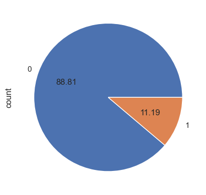

```python
y_train.value_counts().plot.pie(autopct = '%.2f')
```

There seems to exist huge imbalance in train set target variable.... Let's address it by using SMOTE

```python
smote = SMOTE()
X_smote, y_smote = smote.fit_resample(X_train_scaled, y_train)
```

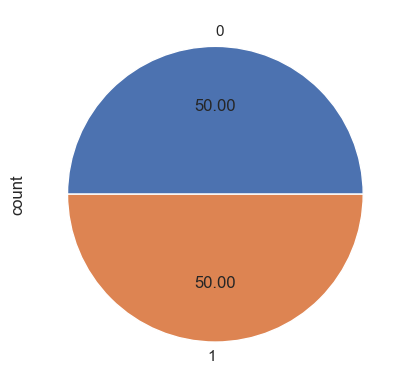

```python
y_smote.value_counts().plot.pie(autopct = '%.2f')
```

#### Model Performance Comparison

As in this case, we need both false positive as well as false negative to be minimal, we would see F1-score which is combined metric considering both FP and FN...

```python
models = [LogisticRegression(), DecisionTreeClassifier(), RandomForestClassifier(), AdaBoostClassifier(), GradientBoostingClassifier(), KNeighborsClassifier(), SVC(), XGBClassifier()]
model_names = ['LogisticRegression', 'DecisionTreeClassifier', 'RandomForestClassifier', 'AdaBoostClassifier', 'GradientBoostingClassifier', 'KNeighborsClassifier', 'SVC', 'XGBClassifier']

accuracy_train = []
accuracy_val = []
f1_val = []
roc_auc_val = []

for model in models:

    mod = model
    mod.fit(X_smote, y_smote)
    y_pred_train = mod.predict(X_smote)
    y_pred_val = mod.predict(X_val_scaled)

    accuracy_train.append(accuracy_score(y_smote, y_pred_train))
    accuracy_val.append(accuracy_score(y_val, y_pred_val))
    f1_val.append(f1_score(y_val, y_pred_val))
    roc_auc_val.append(roc_auc_score(y_val, y_pred_val))

data = {'Modelling Algorithm': model_names, 'Train Accuracy': accuracy_train, 'Validation Accuracy': accuracy_val, 'F-1 Score': f1_val, 'ROC AUC': roc_auc_val}

data = pd.DataFrame(data)

data['Difference'] = ((np.abs(data['Train Accuracy'] - data['Validation Accuracy'])) * 100) / (data['Train Accuracy'])

data.sort_values(by='Difference')
```

|  | Modelling Algorithm | Train Accuracy | Validation Accuracy | F-1 Score | ROC AUC | Difference |
| --- | --- | --- | --- | --- | --- | --- |
| 3 | AdaBoostClassifier | 0.894326 | 0.877223 | 0.596067 | 0.840666 | 1.912415 |
| 0 | LogisticRegression | 0.889752 | 0.857756 | 0.585714 | 0.867678 | 3.596049 |
| 4 | GradientBoostingClassifier | 0.916656 | 0.874617 | 0.613422 | 0.873103 | 4.586135 |
| 6 | SVC | 0.906451 | 0.857449 | 0.590308 | 0.875690 | 5.405864 |
| 7 | XGBClassifier | 0.969838 | 0.897915 | 0.578481 | 0.774007 | 7.415959 |
| 5 | KNeighborsClassifier | 0.936807 | 0.845953 | 0.543389 | 0.827108 | 9.698210 |
| 2 | RandomForestClassifier | 0.999763 | 0.891324 | 0.574174 | 0.782563 | 10.846408 |
| 1 | DecisionTreeClassifier | 0.999763 | 0.874310 | 0.498778 | 0.732036 | 12.548222 |

As we can observe above, Grad Boost classifier seems not to be over optimistic and performing better when you notice all the metrics... So, Lets, choose it and tune and see whether we can improve it furthermore...

#### Hypeparameter Tuning

```python
param_grid = {
    'n_estimators': [100, 200, 300],
    'learning_rate': [0.1, 0.01, 0.001],
    'max_depth': [3, 4, 5]
}

gb_classifier = GradientBoostingClassifier(random_state=42)

grid_search = GridSearchCV(gb_classifier, param_grid, cv=5)
grid_search.fit(X_smote, y_smote)

best_params = grid_search.best_params_
best_params
```

```
{'learning_rate': 0.1, 'max_depth': 5, 'n_estimators': 200}
```

Took more than a hour to complete around 135 fits... Now let's use the best params to train the model with...

#### Model training and accuracy check with validation set

```python
gb_classifier_best = GradientBoostingClassifier(random_state=42, **best_params)

gb_classifier_best.fit(X_smote, y_smote)
```

```
GradientBoostingClassifier(max_depth=5, n_estimators=200, random_state=42)
```

```python
y_pred_train = gb_classifier_best.predict(X_smote)
y_pred_val = gb_classifier_best.predict(X_val_scaled)

train_accuracy = accuracy_score(y_smote, y_pred_train)
val_accuracy = accuracy_score(y_val, y_pred_val)
f1 = f1_score(y_val, y_pred_val)
roc_auc = roc_auc_score(y_val, y_pred_val)

difference = ((np.abs(train_accuracy - val_accuracy) * 100) / (train_accuracy))
```

```python
(train_accuracy, val_accuracy, f1, roc_auc, difference)
```

```
(0.9538727076591155,
 0.8948497854077253,
 0.6128668171557562,
 0.8225537731499493,
 6.18771475244715)
```

Let's look at few more metrics to evaluate the model now with the test set which has had no contact with train and validatation set so far...

#### Accuracy check with test set

```python
y_pred_test = gb_classifier_best.predict(X_test_scaled)

print(f'\nAccuracy Score: {accuracy_score(y_test, y_pred_test)}', end = f"\n{'_'*60}\n\n")

print(f'Confusion Matrix:\n\n {confusion_matrix(y_test, y_pred_test)}', end = f"\n{'_'*60}\n\n")

print(f'Classification Report:\n\n {classification_report(y_test, y_pred_test)}')
```

```
Accuracy Score: 0.8995708154506438
____________________________________________________________

Confusion Matrix:

 [[6674  554]
 [ 265  662]]
____________________________________________________________

Classification Report:

               precision    recall  f1-score   support

           0       0.96      0.92      0.94      7228
           1       0.54      0.71      0.62       927

    accuracy                           0.90      8155
   macro avg       0.75      0.82      0.78      8155
weighted avg       0.91      0.90      0.91      8155
```